# Amalik03_FinalHomeworkCode_02

Assignment 2: Titis in the Mist…

Allister Malik

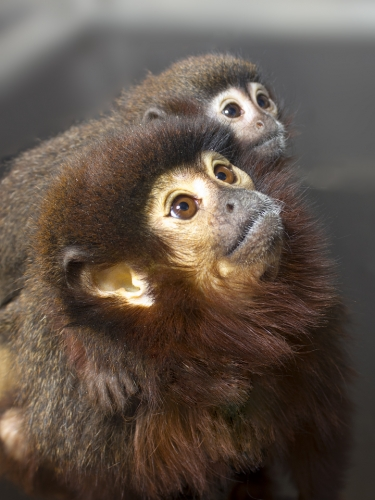

EY: We have the same Titi monkey photo. I like how you centered it.

# AN588 Homework Assignment 2

## Context

Every Saturday morning, at the same time, a primatologist goes and sits in the forest to listen for titi monkey calls, counting the number of calls they hear in a 2 hour window from 5am to 7am. Based on previous knowledge, she believes that the mean number of calls she will hear in that time is exactly 15. Let X represent the appropriate Poisson random variable of the number of calls heard in each monitoring session.

```r
library(manipulate)
library(tidyverse)
```

## What is the probability that she will hear more than 8 calls during any given session?

```r
x <- 8
l <- 15
eightplus <- ppois(q = x, lambda = l, lower.tail = FALSE) #Probabilities of successfully being more than 8 calls

eightplus #Reports the probability of hearing more than 8 calls from the Titi monkeys
```

```
## [1] 0.9625535
```

EY: I also used ppois here with the lower.tail = FALSE. I think since it was asking for more than 8 calls your x should be from 9:30.

AM: According to the help document, I need to do 8:20 to include 9 because setting lower tail to false finds probability[X>x]. I changed my x <- 8:30 to 8 since problem does not ask for a range. I also removed my barplot since it was not asked for.

## What is the probability that she will hear no calls in a session?

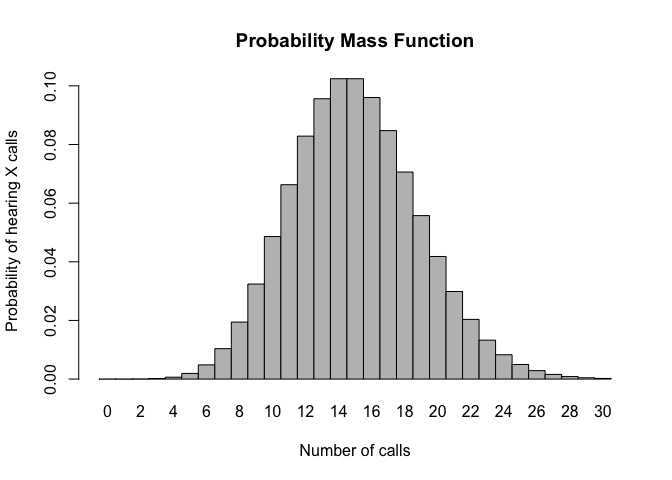

```r
x <- 0:30
l <- 15
probset <- dpois(x = x, lambda = l) #Vector of probabilities of hearing x calls, ranging from x=0 calld to x=30 calls, with a poisson distribution
barplot(probset, names.arg = x, space = 0, xlab = "Number of calls", ylab = "Probability of hearing X calls", main = "Probability Mass Function") #plots the probabilities in prob
```

```r
probset[1] # Probability of hearing 0 calls
```

```
## [1] 3.059023e-07
```

EY: Its nice that you have the entire probability mass function printed. Personally I might change the label of the Y-axis to something more descriptive. Its hard to read Pr(X=x) and immediately know what it means.

AM: Altered y axis label. It makes sense statistically, but I understand how it may cause confusion for laypeople.

## What is the probability that she will hear exactly 3 calls in a session?

```r
x <- 3
l <- 15
threecalls <- dpois(x = x, lambda = l) #Vector of probabilities of hearing x calls, ranging from x=0 calld to x=30 calls with poisson distribution
threecalls # Probability of hearing 3 calls
```

```
## [1] 0.0001720701
```

```r
#Is there a better way to print when x=3 other than indexing the dpois vector (Other than starting the plot at 3 or just plotting 3)?
```

EY: I think probset[4] is perfectly fine way to print. I set x<-3 since the question was only asking for exactly 3 calls.  
I appreciated Emily’s recommendation to set x to 3 rather than a range(previously known as probset) to just show the necessary probability. I changed all my code for the problems that asked similar questions.

## Plot the relevant Poisson mass function over the values in range 0 ≤ x ≤ 30.

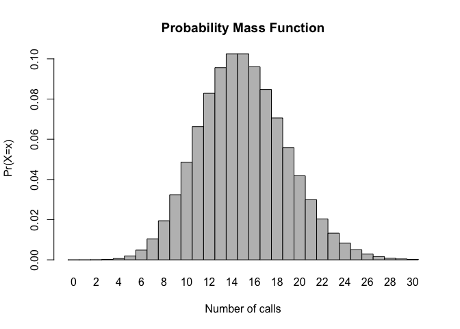

```r
x <- 0:30
l <- 15
probset <- dpois(x = x, lambda = l) #Vector of probabilites using Poisson distribution of 0 to 30
barplot(probset, names.arg = x, space = 0, xlab = "Number of calls", ylab = "Pr(X=x)", main = "Probability Mass Function") #Plots the Poisson distribution
```

EY: I did this the same way.  
## Simulate 104 results from this distribution (i.e., 2 years of Saturday monitoring sessions).

```r
SimCalls <- rpois(104, lambda = l) #Vector of length 104 contain all th enumber of calls recorded(ranging from 0 calls to 30 calls, using the Poisson distribution set in the variable probset)
SimCalls
```

```
##   [1] 15 10 25 13 18 16 11 19 15 19 18 16 16 18 13 22 18 13 20 20  9 22 13 11 11
##  [26] 14 20 17 12 15 14 12  6 12 14 19 13 13 20 13 18 14 15 12 11 10 17 21 10 20
##  [51] 16 12  9 17 15 21 21 12 18 17 19 20 17 14 15 16 17 22 10 11 13 21  9 19 14
##  [76] 16 13 14 11 14 15 14 25 14 13 12 19 22  9 14 16 13 10 18 17 11 17 15 13 12
## [101] 16 17 17 20
```

## Plot the simulated results using hist() and use xlim() to set the horizontal limits to be from 0 to 30. How does your histogram compare to the shape of the probability mass function you plotted above?

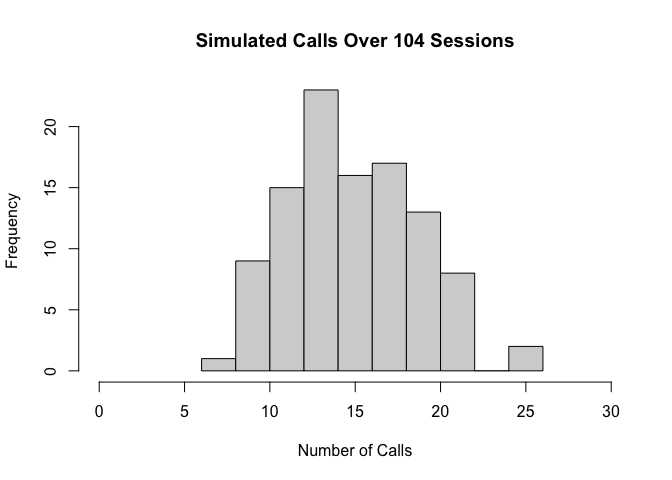

```r
hist(SimCalls, xlim = c(0, 30), xlab = "Number of Calls", ylab = "Frequency", main = "Simulated Calls Over 104 Sessions") #histogram of SimCall as a freqiency
```

Compared to the probability mass function, the histogram has a smaller range and thus, a smaller distribution.

EY: I did this the same way. I like how you printed out the 104 results since every time the code is run it spits out a different set. It made sense to set xlim from 0:30 but why did you set ylim from 0:30 too? It would be very unlikely but maybe you could get more than 30 sessions with the same number of calls.

I did it because when ylim was not set, the bar would extend past the y axis so I chose a random number so the axis covered most of the frequencies. They are correct that it may not always be the case and can be more than 30. I removed ylim because I dont know what I should set it to (other than 104), with a mathematical/statistical explanation.

## Reflection

This assignment was hard to start because I did not understand how the distribution functions worked and which ones to use. I overcame this challenge by rereading the Module 8 topics until I had a better understanding; I had to read the module about 4-5 times until I grasped the uses of the different functions in them. I also faced an issue with the first part, I didn’t know how to show the plot as Pr(X>x). Originally I was simply plotting from 0 to 30 calls and subtracting the cumulative probability of x=8 from x=30 to get the number of cumulative probability of the number of calls from 9 to 30. But this was resolved when I was rereading Module 8 and using “?ppois” and setting the parameter “lower.tail” to FALSE, which simplified my code. Additionally, like the previous challenge, I didn’t realize that “rpois” function could simulate results until I read that “rpois” exists from Module 8.

I believe I understand how the “pois” functions work. After using the “?ppois”, I learned many of the parameters of the function and how I can edit it to satisfy the needs of the plot. This was also a learning experience because I realized I missed quite a bit of information from Module 8 that would have made this assignment a lot faster. This assignment was slightly difficult, but I think it was due to me not understanding the concepts at first. After I figured it out, plotting the different distributions and graphs was very enjoyable and satisfying to create.